# macpie

```r
devtools::load_all()


library(Seurat)
library(edgeR)
library(dplyr)
library(leidenbase)
library(gridExtra)
library(enrichR)
library(parallel)
library(mcprogress)
library(ggsci)
library(ggiraph)
library(pheatmap)
library(tidyr)
library(tibble)
library(enrichR)
library(variancePartition)
library(glmGamPoi)
library(PoiClaClu)
library(Matrix)
library(data.table)


# Define project variables
project_name <- "PMMSq033"
project_metadata <- system.file("extdata/PMMSq033/PMMSq033_metadata_drugnames.csv", package = "macpie")

# Load metadata
metadata <- read_metadata(project_metadata)
metadata$Time <- as.factor(metadata$Time)
metadata$Concentration_1 <- as.factor(metadata$Concentration_1)
colnames(metadata)
```

```
#>  [1] "Plate_ID"        "Well_ID"         "Row"             "Column"
#>  [5] "Species"         "Cell_type"       "Model_type"      "Time"
#>  [9] "Unit"            "Treatment_1"     "Concentration_1" "Unit_1"
#> [13] "Sample_type"     "Barcode"         "Project"
```

```r
# Validate metadata
validate_metadata(metadata)
```

```
#>
#> Validation Issues:
#> Model_type: Contains special characters.
#>
#> Generating summary table grouped by Plate_ID...
#>   Plate_ID count_Species count_Cell_type count_Model_type count_Time
#> 1 PMMSq033             1               3                3          1
#>   count_Unit count_Treatment_1 count_Concentration_1 count_Unit_1
#> 1          1                36                     4            1
#>   count_Sample_type
#> 1                 3
```

## Introduction

**macpie** supports multi-plate analysis using MACseq data, with features for quality control (QC), batch correction, differential expression (DE) analysis, and pathway enrichment.

This vignette demonstrates a complete workflow for analyzing multiple plates, incorporating plate-specific batch effects. It includes:

- Loading and filtering raw count matrices from two MAC-seq plates (PMMSq033 and PMMSq034).
- Merging with metadata, constructing unique plate and sample identifiers
- Visual QC sample distribution
- Single DE comparison and Multi-DE comparisons

The results from DE comparisons can be used for any downstream analyses such as pathway/geneset enrichment and Profile similarity that we’ve shown in the main vignettes.

### 1. Multi-plates analysis

This section walks through QC and differential expression analysis of two MAC-seq plates with matched layouts.

**Key points**:

- import two macseq plates and check QC for any batch effects (and batch correction)
- use **compute_single_de** and **compute_multi_de** by incorporating batch factor

#### 1.1 Import data and QC

Here we import the raw count matrix and metadata for the first plate, apply QC filters, and generate the tidySeurat object.

Load PMMSq033 and PMMSq034

```r
project_metadata <- system.file("extdata/PMMSq033/PMMSq033_metadata_drugnames.csv", package = "macpie")
metadata <- read_metadata(project_metadata)

pmm33_in <- system.file("extdata/PMMSq033/raw_matrix", package = "macpie")
pmm34_in <- system.file("extdata/PMMSq034/raw_matrix", package = "macpie")
raw_counts_total <- Read10X(data.dir = c(pmm33_in,pmm34_in))
keep <- rowSums(cpm(raw_counts_total) >= 10) >= 2
raw_counts <- raw_counts_total[keep, ]
combined <- CreateSeuratObject(counts=raw_counts,
                               min.cells = 1,
                          min.features = 1)

combined[["percent.mt"]] <- PercentageFeatureSet(combined, pattern = "^mt-|^MT-")
combined[["percent.ribo"]] <- PercentageFeatureSet(combined, pattern = "^Rp[slp][[:digit:]]|^Rpsa|^RP[SLP][[:digit:]]|^RPSA")

#join with metadata
combined$Barcode <- str_replace_all(rownames(combined@meta.data),"[1|2]_","")

combined <- combined %>%
  inner_join(metadata, by = c("Barcode" = "Barcode"))

combined <- combined%>%
  filter(Project == "Current")

#add unique identifier
combined <- combined %>%
  mutate(combined_id = str_c(Treatment_1, Concentration_1, sep = "_")) %>%
  mutate(combined_id = gsub(" ", "", .data$combined_id))

combined$combined_id <- make.names(combined$combined_id)
```

```r
# meta <- meta %>% mutate(Treatment_1 =  ifelse(grepl("^Ada|^Shenali|^EMPTY$", Treatment_1), Treatment_1, paste0("ML_", Treatment_1)))

combined <- combined %>% mutate(orig.ident = ifelse(grepl("1", orig.ident), "PMMSq033","PMMSq034"))
```

Plate layout for both plates:

```r
p <- plot_plate_layout(combined, "nCount_RNA", "combined_id") + facet_wrap(~orig.ident)
girafe(ggobj = p,
  fonts = list(sans = "sans"),
  options = list(
    opts_hover(css = "stroke:black; stroke-width:1px;")
  ))
```

[interactive chart not shown]

We visualize sample grouping across plates using MDS (multidimensional scaling) plots and assess expression variability using RLE plots.

```r
combined_dmso <- combined %>%
  filter(Treatment_1 == "DMSO")
```

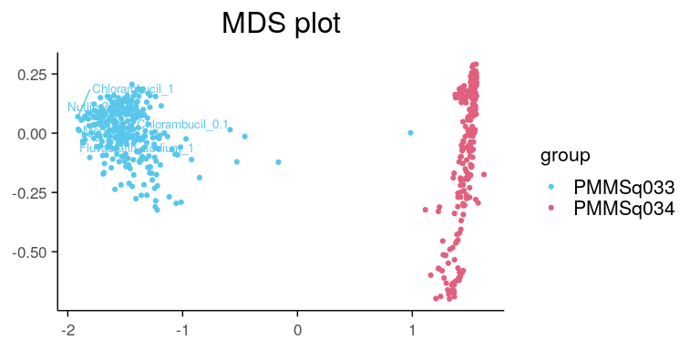

```r
plot_mds(combined, group_by = "orig.ident", label = "combined_id", n_labels = 30)
```

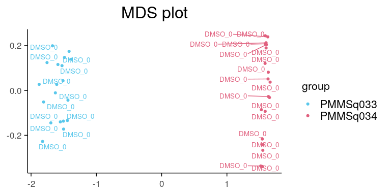

```r
plot_mds(combined_dmso, group_by = "orig.ident", label = "combined_id", n_labels = 30)
```

RLE plots to show before and after using limma_voom for batch correction.

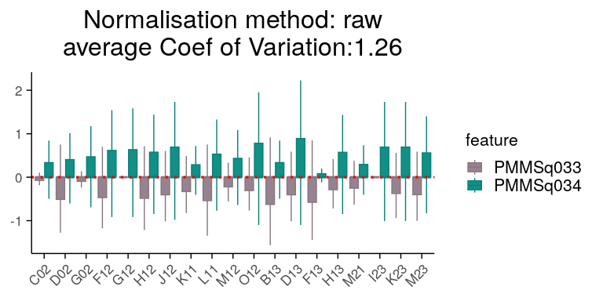

```r
plot_rle(combined_dmso, label_column = "orig.ident", normalisation = "raw") + scale_x_discrete(drop = FALSE) +
  theme(axis.text.x = element_text(angle = 45, hjust = 1))
```

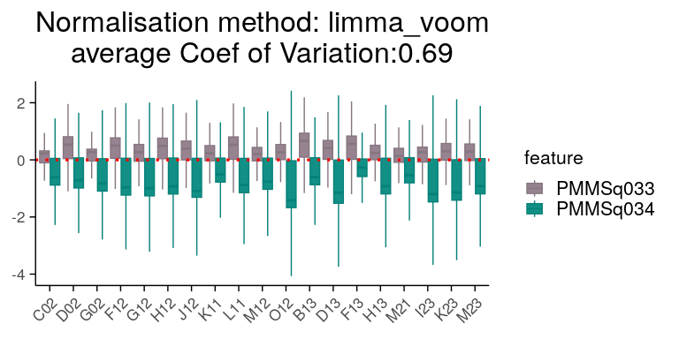

```r
plot_rle(combined_dmso, label_column = "orig.ident", normalisation = "limma_voom") + scale_x_discrete(drop = FALSE) +
  theme(axis.text.x = element_text(angle = 45, hjust = 1))
```

#### 1.2 Single comparison DE analysis

We run differential expression using edgeR between one treatment condition and control (e.g. Staurosporine_0.1 vs DMSO_0), while accounting for plate effects via batch modeling.

First, we look at the volcano plot if no batch correction is used.

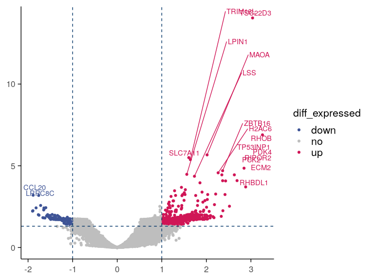

```r
treatment_samples <- "Staurosporine_0.1"
control_samples <- "DMSO_0"
combined_lv_nobatch <- compute_single_de(combined, treatment_samples, control_samples, method =  "limma_voom")
plot_volcano(combined_lv_nobatch, max.overlaps = 10)
```

Then, we compare with the volcano plot after batch correction.

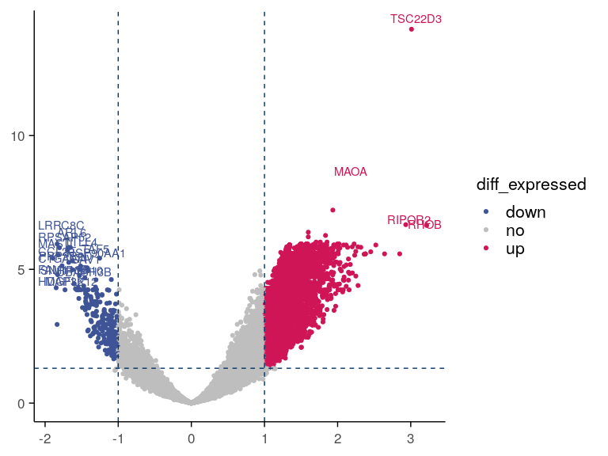

```r
treatment_samples <- "Staurosporine_0.1"
control_samples <- "DMSO_0"
subset <- combined[, grepl(paste0(treatment_samples, "|", control_samples), combined$combined_id)]
batch <- subset$orig.ident
combined_lv <- compute_single_de(combined, treatment_samples, control_samples, method = "limma_voom", batch = batch)
plot_volcano(combined_lv)
```

Check CPM levels for top 6 differentially expressed genes.

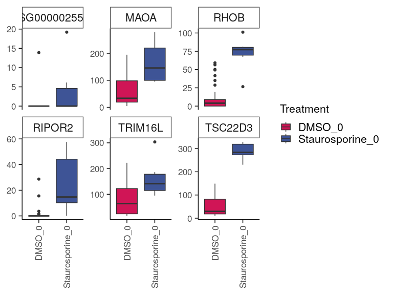

```r
genes <- combined_lv$gene[1:6]
group_by <- "combined_id"
plot_counts(combined,genes, group_by, treatment_samples, control_samples, normalisation = "cpm")
```

Summarise the outputs from single comparison in a table

```r
summarise_de(combined_lv, lfc_threshold = 1, padj_threshold = 0.01, multi=FALSE)
```

```
#> # A tibble: 1 × 6
#>   Total_genes_tested Significantly_upregulated Significantly_downregulated
#>                <int>                     <int>                       <int>
#> 1              25736                     13168                         222
#> # ℹ 3 more variables: Total_significant <int>, Padj_threshold <dbl>,
#> #   Log2FC_threshold <dbl>
```

#### 1.3 Multi-comparison DE analysis

We compare all treatment conditions against the DMSO control. This is especially useful for screening multiple drugs across the plates.

For visualisation purpose, we only use high concentration treatments in this workshop.

```r
treatments <- combined %>%
  filter(Concentration_1 == 10) %>%
  select(combined_id) %>%
  filter(!grepl("DMSO", combined_id)) %>%
  pull() %>%
  unique()
combined <- compute_multi_de(combined, treatments, control_samples = "DMSO_0", method = "edgeR", num_cores = 2, batch = batch)
```

```r
summarise_de(combined, lfc_threshold = 1, padj_threshold = 0.01, multi=TRUE)
```

```
#> # A tibble: 27 × 7
#>    combined_id                Total_genes_tested Significantly_upregulated
#>    <chr>                                   <int>                     <int>
#>  1 Abemaciclib_10                          25736                       127
#>  2 Adavosertib_10                          25736                       125
#>  3 Anastrozole_10                          25736                         0
#>  4 Azd.5991_10                             25736                         1
#>  5 Camptothecin_10                         25736                       829
#>  6 Capivasertib_10                         25736                       126
#>  7 Ceralasertib_10                         25736                       125
#>  8 Chlorambucil_10                         25736                         0
#>  9 Cytarabine_10                           25736                       196
#> 10 Erlotinib_hydrochloride_10              25736                       594
#> # ℹ 17 more rows
#> # ℹ 4 more variables: Significantly_downregulated <int>,
#> #   Total_significant <int>, padj_threshold <dbl>, Log2FC_threshold <dbl>
```

```r
plot_multi_de(combined, group_by = "combined_id", value = "log2FC", p_value_cutoff = 0.01, direction="up", n_genes = 5, control = "DMSO_0", by="fc")
```

[output not shown]